# team.Rmd

Mike Brown and Nathan Marquardt

3/16/2021

```r
library(dplyr)
library(readxl)
```

```r
library(ggplot2)
library(classdata)
library(tidyverse)
```

## Part one: Cleaning Data

Although the three Excel sheets are loaded into R, they are not useful before some cleaning. Manipulate the three imported data frames, so that in the cleaned dataset:

1.The player names and opponent names are factors.

2.All offensive and defensive statistics are numerical. The `Weight` column in biography is also numeric. (Optional: Read `?across` and learn to mutate multiple columns simultaneously using the `across` function in `dplyr`)

3.Change the `Height` column in biography into numeric. (Hint: Use a unit that works well)

```r
# Q1 pt2
defense <- read_xlsx("C:/Users/brown/OneDrive/Desktop/DS202/ds202_lab4/cyclonesFootball2020.xlsx", sheet='Defensive')
defclean <- defense %>%
  mutate(across(Tackles_Solo:Pass_PB, as.numeric))
str(defclean)
```

```
## tibble [372 x 11] (S3: tbl_df/tbl/data.frame)
##  $ Name             : chr [1:372] "Rose, Mike" "Rose, Mike" "Rose, Mike" "Rose, Mike" ...
##  $ Opponent_Opponent: chr [1:372] "Louisiana" "TCU" "Oklahoma" "Texas Tech" ...
##  $ Tackles_Solo     : num [1:372] 2 6 6 3 7 4 7 4 4 2 ...
##  $ Tackles_ASST     : num [1:372] 4 4 5 0 3 1 4 3 9 3 ...
##  $ Tackles_TFL      : num [1:372] 1 0 1.5 1 1 0 1.5 2.5 1.5 0 ...
##  $ Tackles_Sack     : num [1:372] 0 0 0.5 0 0 0 0 1 0 0 ...
##  $ Turnover_FF      : num [1:372] 0 0 0 0 0 0 0 0 0 0 ...
##  $ Turnover_FR      : num [1:372] 0 0 0 0 0 0 0 0 0 0 ...
##  $ Turnover_INT     : num [1:372] 0 1 0 0 1 0 1 1 0 0 ...
##  $ Pass_QBH         : num [1:372] 0 0 1 0 0 0 2 1 0 0 ...
##  $ Pass_PB          : num [1:372] 0 0 0 0 0 1 0 0 1 0 ...
```

```r
offense <- read_xlsx("C:/Users/brown/OneDrive/Desktop/DS202/ds202_lab4/cyclonesFootball2020.xlsx", sheet='Offensive')
offclean <- offense %>%
  mutate(across(Receiving_REC:Passing_INT, as.numeric))
str(offclean)
```

```
## tibble [156 x 12] (S3: tbl_df/tbl/data.frame)
##  $ Name             : chr [1:156] "Akers, Landen" "Akers, Landen" "Akers, Landen" "Akers, Landen" ...
##  $ Opponent_Opponent: chr [1:156] "Louisiana" "TCU" "Oklahoma" "Texas Tech" ...
##  $ Receiving_REC    : num [1:156] 0 2 1 4 0 6 1 0 1 1 ...
##  $ Receiving_YDS    : num [1:156] 0 60 35 34 0 76 11 0 10 2 ...
##  $ Receiving_TD     : num [1:156] 0 0 0 0 0 0 0 0 0 1 ...
##  $ Rushing_ATT      : num [1:156] NA NA NA NA NA NA NA NA NA NA ...
##  $ Rushing_YDS      : num [1:156] NA NA NA NA NA NA NA NA NA NA ...
##  $ Rushing_TD       : num [1:156] NA NA NA NA NA NA NA NA NA NA ...
##  $ Passing_CMP-ATT  : num [1:156] NA NA NA NA NA NA NA NA NA NA ...
##  $ Passing_YDS      : num [1:156] NA NA NA NA NA NA NA NA NA NA ...
##  $ Passing_TD       : num [1:156] NA NA NA NA NA NA NA NA NA NA ...
##  $ Passing_INT      : num [1:156] NA NA NA NA NA NA NA NA NA NA ...
```

```r
#Q1 pt3
biography <- read_xlsx("C:/Users/brown/OneDrive/Desktop/DS202/ds202_lab4/cyclonesFootball2020.xlsx", sheet='Biography')
bioclean <- biography %>% separate(Height, c('feet','inches'), "-",convert = TRUE)%>% mutate(Total_Inches = (12*feet)+inches)
str(bioclean)
```

```
## tibble [116 x 9] (S3: tbl_df/tbl/data.frame)
##  $ Name        : chr [1:116] "Akers, Landen" "Allen, Chase" "Anderson, Ezeriah" "Antoine Jr. , Michal" ...
##  $ Position    : chr [1:116] "Wide Receiver" "Tight End" "Wide Receiver" "Defensive Back" ...
##  $ feet        : int [1:116] 6 6 6 6 6 6 6 6 6 6 ...
##  $ inches      : int [1:116] 0 7 5 0 0 0 3 2 2 2 ...
##  $ Weight      : chr [1:116] "191" "240" "208" "180" ...
##  $ Class       : chr [1:116] "Redshirt Senior" "Redshirt Senior" "Redshirt Freshman" "Freshman" ...
##  $ Hometown    : chr [1:116] "Cedar Rapids, Iowa" "Nixa, Mo." "Seffner, Fla." "Ft. Lauderdale, Fla." ...
##  $ Highschool  : chr [1:116] "Washington" "Nixa" "Armwood" "Cardinal Gibbons" ...
##  $ Total_Inches: num [1:116] 72 79 77 72 72 72 75 74 74 74 ...
```

```r
#Q1 pt1
factor(defclean$Name)
```

```
##   [1] Rose, Mike         Rose, Mike         Rose, Mike
##   [4] Rose, Mike         Rose, Mike         Rose, Mike
##   [7] Rose, Mike         Rose, Mike         Rose, Mike
##  [10] Rose, Mike         Rose, Mike         Rose, Mike
##  [13] Hummel, Jake       Hummel, Jake       Hummel, Jake
##  [16] Hummel, Jake       Hummel, Jake       Hummel, Jake
##  [19] Hummel, Jake       Hummel, Jake       Hummel, Jake
##  [22] Hummel, Jake       Hummel, Jake       Hummel, Jake
##  [25] Vance, O'Rien      Vance, O'Rien      Vance, O'Rien
##  [28] Vance, O'Rien      Vance, O'Rien      Vance, O'Rien
##  [31] Vance, O'Rien      Vance, O'Rien      Vance, O'Rien
##  [34] Vance, O'Rien      Vance, O'Rien      Vance, O'Rien
##  [37] Young, Isheem      Young, Isheem      Young, Isheem
##  [40] Young, Isheem      Young, Isheem      Young, Isheem
##  [43] Young, Isheem      Young, Isheem      Young, Isheem
```

[output cut: 110 more lines]

```r
factor(defclean$Opponent_Opponent)
```

```
##   [1] Louisiana     TCU           Oklahoma      Texas Tech    Oklahoma St.
##   [6] Kansas        Baylor        Kansas State  Texas         West Virginia
##  [11] Oklahoma      Oregon        Louisiana     TCU           Oklahoma
##  [16] Texas Tech    Oklahoma St.  Kansas        Baylor        Kansas State
##  [21] Texas         West Virginia Oklahoma      Oregon        Louisiana
##  [26] TCU           Oklahoma      Texas Tech    Oklahoma St.  Kansas
##  [31] Baylor        Kansas State  Texas         West Virginia Oklahoma
##  [36] Oregon        Louisiana     TCU           Oklahoma      Texas Tech
##  [41] Oklahoma St.  Kansas        Baylor        Kansas State  Texas
##  [46] West Virginia Oklahoma      Oregon        Louisiana     TCU
##  [51] Oklahoma      Texas Tech    Oklahoma St.  Kansas        Baylor
##  [56] Kansas State  Texas         West Virginia Oklahoma      Oregon
##  [61] Louisiana     TCU           Oklahoma      Texas Tech    Oklahoma St.
##  [66] Kansas        Baylor        West Virginia Oklahoma      Louisiana
##  [71] TCU           Oklahoma      Texas Tech    Oklahoma St.  Kansas
```

[output cut: 61 more lines]

```r
factor(offclean$Opponent_Opponent)
```

```
##   [1] Louisiana     TCU           Oklahoma      Texas Tech    Oklahoma St.
##   [6] Kansas        Baylor        Kansas State  Texas         West Virginia
##  [11] Oklahoma      Oregon        Oklahoma      Texas Tech    Oklahoma St.
##  [16] Kansas        Baylor        Kansas State  Texas         West Virginia
##  [21] Oklahoma      Oregon        Louisiana     TCU           Oklahoma
##  [26] Texas Tech    Oklahoma St.  Kansas        Baylor        Kansas State
##  [31] Texas         West Virginia Oklahoma      Oregon        Louisiana
##  [36] TCU           Oklahoma      Texas Tech    Oklahoma St.  Kansas
##  [41] Baylor        Kansas State  Texas         West Virginia Oklahoma
##  [46] Oregon        Louisiana     TCU           Oklahoma      Texas Tech
##  [51] Oklahoma St.  Kansas        Baylor        Kansas State  Texas
##  [56] West Virginia Oklahoma      Oregon        Louisiana     TCU
##  [61] Oklahoma      Texas Tech    Oklahoma St.  Kansas        Baylor
##  [66] Kansas State  Texas         Oklahoma      Oregon        Louisiana
##  [71] TCU           Oklahoma      Texas Tech    Oklahoma St.  Kansas
```

[output cut: 18 more lines]

```r
factor(offclean$Name)
```

```
##   [1] Akers, Landen      Akers, Landen      Akers, Landen
##   [4] Akers, Landen      Akers, Landen      Akers, Landen
##   [7] Akers, Landen      Akers, Landen      Akers, Landen
##  [10] Akers, Landen      Akers, Landen      Akers, Landen
##  [13] Brock, Jirehl      Brock, Jirehl      Brock, Jirehl
##  [16] Brock, Jirehl      Brock, Jirehl      Brock, Jirehl
##  [19] Brock, Jirehl      Brock, Jirehl      Brock, Jirehl
##  [22] Brock, Jirehl      Hutchinson, Xavier Hutchinson, Xavier
##  [25] Hutchinson, Xavier Hutchinson, Xavier Hutchinson, Xavier
##  [28] Hutchinson, Xavier Hutchinson, Xavier Hutchinson, Xavier
##  [31] Hutchinson, Xavier Hutchinson, Xavier Hutchinson, Xavier
##  [34] Hutchinson, Xavier Nwangwu, Kene      Nwangwu, Kene
##  [37] Nwangwu, Kene      Nwangwu, Kene      Nwangwu, Kene
##  [40] Nwangwu, Kene      Nwangwu, Kene      Nwangwu, Kene
##  [43] Nwangwu, Kene      Nwangwu, Kene      Nwangwu, Kene
```

[output cut: 38 more lines]

```r
factor(bioclean$Name)
```

```
##   [1] Akers, Landen          Allen, Chase           Anderson, Ezeriah
##   [4] Antoine Jr. , Michal   Assalley, Connor       Azunna, Arnold
##   [7] Bailey, Cordarrius     Bailey, JaQuan         Bailey, Joshua
##  [10] Bitter, Aidan          Bouman, Aidan          Brock, Jirehl
##  [13] Cassady, Mason         Chambers, Mason        Clark, Blake
##  [16] Coberley, Beau         Davis, Dae'Shawn       Dean, Easton
##  [19] Dekkers, Hunter        Downing, Trevor        Doxzon, Blaze
##  [22] Dunkleberger, Benjamin Dunn, Corey            Edwards II, Virdel
##  [25] Eisworth II, Greg      Foster, Sean           Gaye, Answer
##  [28] Gibson, Hayes          Greiner, Derek         Greiner, Seth
##  [31] Guess, Connor          Hall, Breece           Hanika, DeShawn
##  [34] Hathcock, Koby         Hester, Jack           Hillmann, Jacob
##  [37] Horne, Aric            Hudson, Robert         Hufford, Jarrod
##  [40] Hummel, Jake           Hummel, Levi           Hutchinson, Xavier
##  [43] Jackson, Daniel        Jackson, Kendell       James, D'Shayne
```

[output cut: 25 more lines]

## Part two: Tidying

For the following questions, work on the cleaned data frames `defClean`, `offClean`, and `bioClean`.

1.Reformat the `offClean` data frame into a tidy format using `pivot_longer`. The type of statistic (Receiving_REC for the number of receivings, Receiving_YDS for receiving yards) is added as a new key column named `stat`.

Answer:

```r
offpvt <- pivot_longer(offclean,Receiving_REC:Passing_INT, names_to= 'stat', values_to='scale')
head(offpvt)
```

```
## # A tibble: 6 x 4
##   Name          Opponent_Opponent stat          scale
##   <chr>         <chr>             <chr>         <dbl>
## 1 Akers, Landen Louisiana         Receiving_REC     0
## 2 Akers, Landen Louisiana         Receiving_YDS     0
## 3 Akers, Landen Louisiana         Receiving_TD      0
## 4 Akers, Landen Louisiana         Rushing_ATT      NA
## 5 Akers, Landen Louisiana         Rushing_YDS      NA
## 6 Akers, Landen Louisiana         Rushing_TD       NA
```

2.Show on the distributions of the offensive statistics. The distribution of each offensive statistic should be shown in a separate facet. Explain the patterns you see.

Answer:

[figure not shown]

```r
ggplot(aes(x=Opponent_Opponent, y=scale), data=offpvt) + geom_point()+theme(axis.text.x=element_text(angle=90, hjust=1))+facet_grid(Name~stat)+xlab('Opposing Team')+ylab('Scale of Statistic')+ggtitle('Distribution of Offensive Statistics')
```

3.Did ISU have better offensive against Oregon or Oklahoma? Answer this question by creating a scatterplot with the x- and y-axes being the receiving yards of the ISU players against these two opponents. A large number of receiving yards indicates good offense.

Answer:

```r
  oo <- filter(offpvt, (Opponent_Opponent == "Oklahoma"| Opponent_Opponent=="Oregon") & stat=="Receiving_YDS")

okla <- filter(oo, Opponent_Opponent=="Oklahoma") %>% group_by(Name,stat,Opponent_Opponent) %>% summarise(avg=mean(scale, na.rm=TRUE))
ore <- filter(oo, Opponent_Opponent=="Oregon") %>% group_by(Name,stat,Opponent_Opponent) %>% summarise(avg=mean(scale, na.rm=TRUE))
oklaore <- full_join(okla,ore)
```

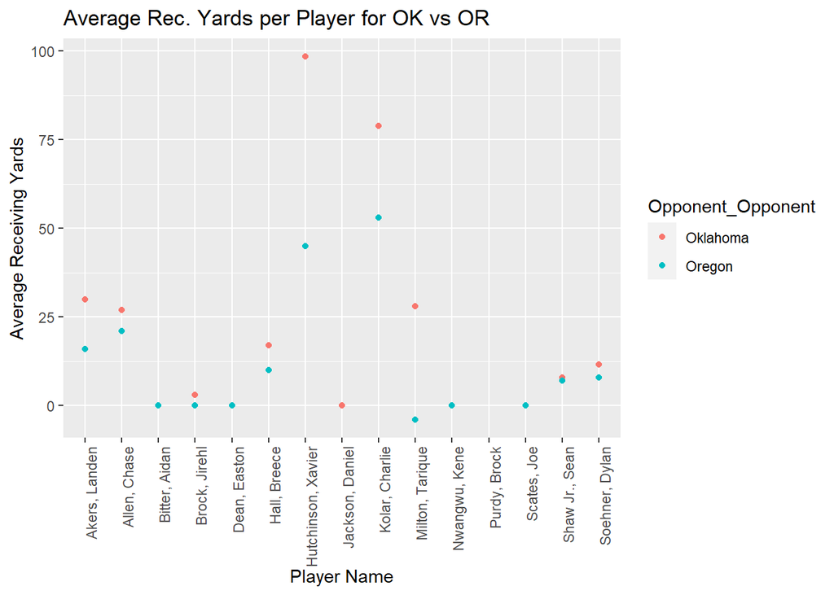

```r
ggplot(aes(x=Name, y=avg,color=Opponent_Opponent), data=oklaore)+xlab("Player Name")+ylab("Average Receiving Yards") + ggtitle("Average Rec. Yards per Player for OK vs OR") +geom_point()+theme(axis.text.x=element_text(angle=90, hjust=1))
```

Now turn our attention to the player biography.

4.Separate the `Hometown` column into two columns, namely, the city and the state where the player comes from. Print the first two rows of these two columns. (Hint: look at the `sep=` argument of `separate`)

Answer:

```r
bioclean2 <- separate(bioclean, Hometown, into = c("City","State"), ",")
bioclean3 <- bioclean2 %>% select(City, State)
head(bioclean3, n=2)
```

```
## # A tibble: 2 x 2
##   City         State
##   <chr>        <chr>
## 1 Cedar Rapids " Iowa"
## 2 Nixa         " Mo."
```

5.How many players are there from each state?

Answer:

```r
hmtwncnt <- bioclean2 %>% group_by(State) %>% summarise(count = n())
head(hmtwncnt)
```

```
## # A tibble: 6 x 2
##   State        count
##   <chr>        <int>
## 1 " Ariz."         4
## 2 " Ark."          1
## 3 " Australia"     1
## 4 " Calif."        2
## 5 " Fla."         14
## 6 " Ga."           3
```

## Part three: Joining data frames

1.Find which states do the ISU players (both defensive and offensive) come from. Create an appropriate numerical or graphical summary.

Answer:

```r
table(hmtwncnt$State)
```

```
##
##      Ariz.       Ark.  Australia     Calif.       Fla.        Ga.       Ill.
##          1          1          1          1          1          1          1
##       Iowa       Kan.       Mich      Mich.      Minn.      Miss.        Mo.
##          1          1          1          1          1          1          1
##       Neb.       Ohio      Okla.        Pa.       S.D.      Texas       Wis.
##          1          1          1          1          1          1          1
```

Michigan is recorded twice as “Mich” and “Mich.”

2.How does the performance of quarterback Brock Purdy relate to the performance of the ISU team?

Answer:

```r
team <- full_join(offclean,defclean)
brock <- filter(team, Name=="Purdy, Brock" & Passing_YDS>=250 & Passing_TD>=1 & Passing_INT <= 1)
defpvt <- pivot_longer(defclean,Tackles_Solo:Pass_PB, names_to= 'stat', values_to='scale')
isudefense <- filter(defpvt, Opponent_Opponent == "Oklahoma"|Opponent_Opponent =="Texas"|Opponent_Opponent =="Texas Tech")
isudefstat <- isudefense %>% group_by(Opponent_Opponent,stat) %>% summarise(avg_mean=mean(scale,na.rm=TRUE))
isudefstattotal <- defpvt %>% group_by(Opponent_Opponent,stat) %>% summarise(avg_mean=mean(scale,na.rm=TRUE))
```

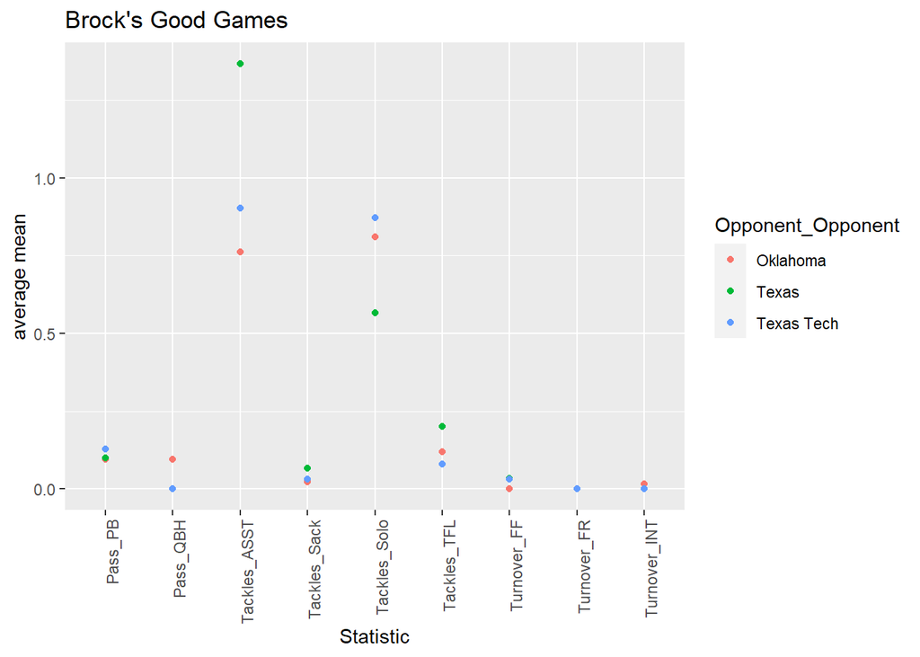

```r
isudefstattotal2 <- isudefstattotal %>% filter(Opponent_Opponent != "Oklahoma" & Opponent_Opponent!="Texas Tech" & Opponent_Opponent != "Texas")

ggplot(aes(x=stat, y=avg_mean, color=Opponent_Opponent), data=isudefstat)+geom_point()+theme(axis.text.x=element_text(angle=90, hjust=1))+xlab('Statistic') + ylab('average mean')+ggtitle("Brock's Good Games")
```

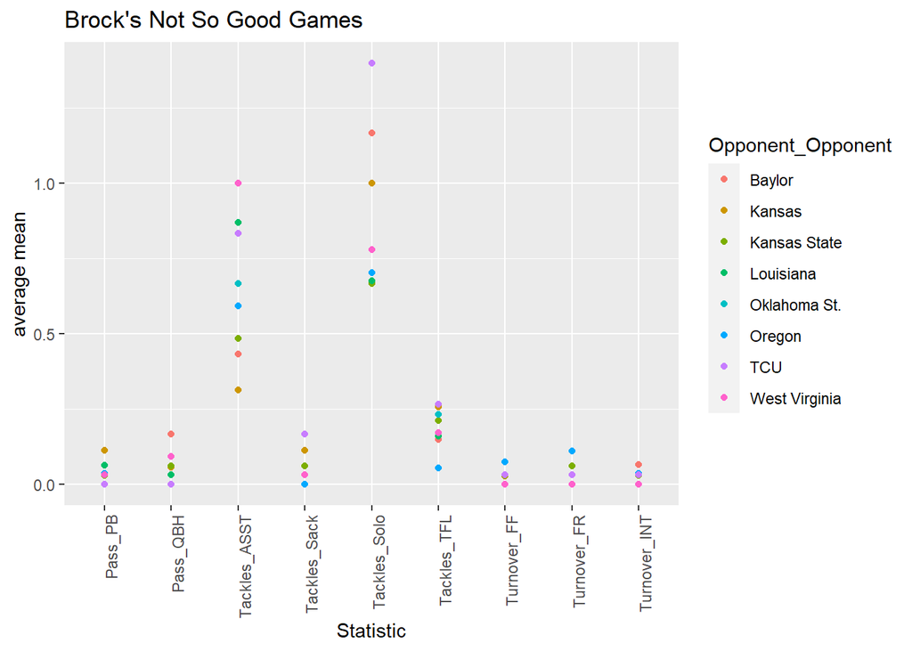

```r
ggplot(aes(x=stat, y=avg_mean, color=Opponent_Opponent), data=isudefstattotal2)+geom_point()+theme(axis.text.x=element_text(angle=90, hjust=1))+xlab('Statistic') + ylab('average mean')+ggtitle("Brock's Not So Good Games")
```

```r
offpvt <- pivot_longer(offclean,Receiving_REC:Passing_INT, names_to= 'stat', values_to='scale')
running <- filter(offpvt, stat=="Rushing_ATT" | stat=="Rushing_YDS" | stat=="Rushing_TD")
isurunb <- filter(running, Opponent_Opponent == "Oklahoma"|Opponent_Opponent =="Texas"|Opponent_Opponent =="Texas Tech")

isuoffstat <- isurunb %>% group_by(Opponent_Opponent,stat) %>% summarise(avg_mean=mean(scale,na.rm=TRUE))
isuoffstattotal <- running %>% group_by(Opponent_Opponent,stat) %>% summarise(avg_mean=mean(scale,na.rm=TRUE))
```

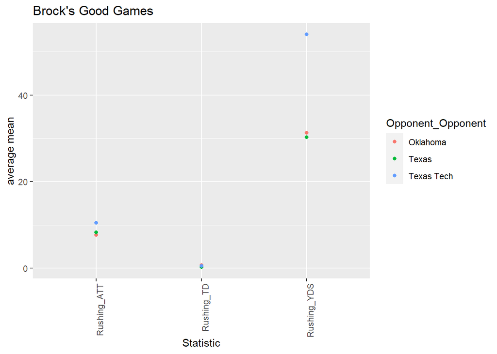

```r
isuoffstattotal2 <- isuoffstattotal %>% filter(Opponent_Opponent != "Oklahoma" & Opponent_Opponent!="Texas Tech" & Opponent_Opponent != "Texas")

ggplot(aes(x=stat, y=avg_mean, color=Opponent_Opponent), data=isuoffstat)+geom_point()+theme(axis.text.x=element_text(angle=90, hjust=1))+xlab('Statistic') + ylab('average mean')+ggtitle("Brock's Good Games")
```